# SI 699 Demo

Team 1

2024-03-12

## Intro to R

```r
# install.packages('tidyverse')
# install.packages('lme4', type = 'source')
# install.packages("Matrix")
library(tidyverse)
library(lme4)
load("dragons.RData")
head(dragons)
```

```
##   testScore bodyLength mountainRange site
## 1 16.147309   165.5485      Bavarian    a
## 2 33.886183   167.5593      Bavarian    a
## 3  6.038333   165.8830      Bavarian    a
## 4 18.838821   167.6855      Bavarian    a
## 5 33.862328   169.9597      Bavarian    a
## 6 47.043246   168.6887      Bavarian    a
```

## Mixed Effects Regression

A mixed effects model contains both **fixed effects** and **random effects.** A fixed effect is a parameter that does not vary. Random effects are parameters that are random variables.

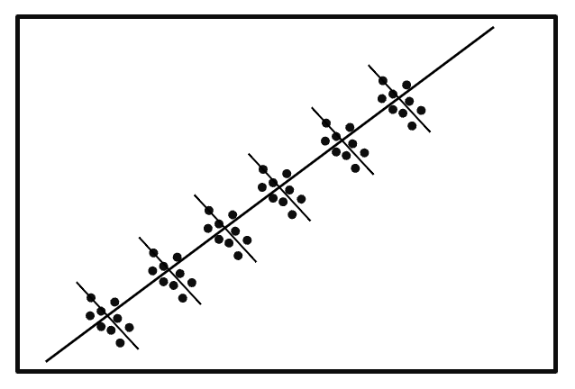

It follows the same assumptions are standard OLS regression: 1. linearity 2. no outliers 3. homoscedasticity 4. residuals are normally distributed 5. no multicollinearity

You should consider using a mixed effects model when you have **repeated measures from the same unit of observation.**

```r
dragons$bodyLength2 <- scale(dragons$bodyLength, center = TRUE, scale = TRUE)
mixed.lmer <- lmer(testScore ~ bodyLength2 + (1|mountainRange), data = dragons)
summary(mixed.lmer)
```

```
## Linear mixed model fit by REML ['lmerMod']
## Formula: testScore ~ bodyLength2 + (1 | mountainRange)
##    Data: dragons
##
## REML criterion at convergence: 3985.6
##
## Scaled residuals:
##     Min      1Q  Median      3Q     Max
## -3.4815 -0.6513  0.0066  0.6685  2.9583
##
## Random effects:
##  Groups        Name        Variance Std.Dev.
##  mountainRange (Intercept) 339.7    18.43
##  Residual                  223.8    14.96
## Number of obs: 480, groups:  mountainRange, 8
##
## Fixed effects:
##             Estimate Std. Error t value
## (Intercept)  50.3860     6.5517   7.690
## bodyLength2   0.5377     1.2750   0.422
##
## Correlation of Fixed Effects:
##             (Intr)
## bodyLength2 0.000
```

## Multinomial Logistic Regression (Discrete Choice Model)

#### Based on TO566 class materials

- *Logistic regression*: Models binary outcomes.
- *Multinomial logistic regression*: The model to use when your outcome variable takes one of several options.
- **Example**: A consumer has the option to purchase a product from one of several brands.

### Applications

- Market share and pricing analysis (how would increasing prices affect market share?)
- New technology adoption (what factors influence the adoption of a new technology?)
- Competitive analysis (how do product/service features influence consumer preferences?)

### The Math

- Choices are modeled by utility functions: $u_i = \alpha_1 + \beta_pPrice_1 + \beta_bBrand_1$
  - For each choice, the model coefficients reflect the effect of one unit change in the X variable on the log odds when other variables are held constant.
    $$\log\frac{p(x)}{(1 - p(x))} = \alpha + \beta_0X + \cdots \beta_nX_n$$

Therefore, the probability that a consumer chooses $j$ (product $j's$ market share) is:
$$P(Y_i = j) = \frac{e^{\beta_{0j} + \beta_{1j}x_1 + \ldots +
\beta_{pj}x_p}}{1 + \sum_{k=1}^{J-1}e^{\beta_{0k} + \beta_{1k}x_1 +
\ldots + \beta_{pk}x_p}}$$

Some math resources:

- https://web.stanford.edu/class/archive/stats/stats200/stats200.1172/Lecture26.pdf
- https://towardsdatascience.com/a-simple-interpretation-of-logistic-regression-coefficients-e3a40a62e8cf
- https://towardsdatascience.com/how-to-interpret-the-odds-ratio-with-categorical-variables-in-logistic-regression-5bb38e3fc6a8

### Example

- Using a dataset of heating choices by household (single family houses in California)
  - dependent variables (choices of heating systems):
    - ec: electric central
    - er: electric room
    - gc: gas central
    - gr: gas room
    - hp: heat pump
  - independent variables (characteristics of choices, characteristics of households)
    - characteristics of the choices (heating options in this case)
      - ic: installation cost (one time cost)
      - oc: operation cost (yearly operating cost)
    - characteristics of households
      - income
      - agehed: age of the head of household
      - rooms: number of rooms in the house
      - region: northern coastal, southern coastal, mountain region, central valley

```r
options(warn = -1)
library(mlogit)
library(dfidx)
# Note mlogit requires data in long format
# The multinom function from the nnet package does not require reshaping data
library(caret)
```

```r
library(tidyverse)

data("Heating") # dataset of heating technologies chosen by households

# Let's look at market shares
prop.table(table(Heating$depvar))
```

```
##
##         gc         gr         ec         er         hp
## 0.63666667 0.14333333 0.07111111 0.09333333 0.05555556
```

```r
# long format with two indexes: household index and choice index
heating <- dfidx(Heating, choice="depvar", varying=3:12) # varying=variables that vary across choices
# Create your multinomial regression model
heat_model <- mlogit(depvar ~ ic + oc, data = heating)

# Negative coefficient means less preferred option
# R^2 values tend to be quite small for logit models
summary(heat_model) # baseline: ec
```

```
##
## Call:
## mlogit(formula = depvar ~ ic + oc, data = heating, method = "nr")
##
## Frequencies of alternatives:choice
##       ec       er       gc       gr       hp
## 0.071111 0.093333 0.636667 0.143333 0.055556
##
## nr method
## 6 iterations, 0h:0m:0s
## g'(-H)^-1g = 9.58E-06
## successive function values within tolerance limits
##
## Coefficients :
##                   Estimate  Std. Error z-value  Pr(>|z|)
## (Intercept):er  0.19459102  0.20424212  0.9527 0.3407184
## (Intercept):gc  0.05213336  0.46598878  0.1119 0.9109210
## (Intercept):gr -1.35058266  0.50715442 -2.6631 0.0077434 **
## (Intercept):hp -1.65884594  0.44841936 -3.6993 0.0002162 ***
## ic             -0.00153315  0.00062086 -2.4694 0.0135333 *
## oc             -0.00699637  0.00155408 -4.5019 6.734e-06 ***
## ---
## Signif. codes:  0 '***' 0.001 '**' 0.01 '*' 0.05 '.' 0.1 ' ' 1
##
## Log-Likelihood: -1008.2
## McFadden R^2:  0.013691
## Likelihood ratio test : chisq = 27.99 (p.value = 8.3572e-07)
```

Let’s examine the coefficients

```r
coef(heat_model)
```

```
## (Intercept):er (Intercept):gc (Intercept):gr (Intercept):hp             ic
##    0.194591023    0.052133359   -1.350582664   -1.658845944   -0.001533153
##             oc
##   -0.006996368
```

```r
# - ec: electric central
# - er: electric room
# - gc: gas central
# - gr: gas room
# - hp: heat pump
```

Utility function for central electric (ec) $0 – 0.0015 \cdot ic – 0.0070 \cdot oc$

You can also examine the probabilities for each consumer and averaging all will give you the market share.

```r
head(heat_model$probabilities)
```

```
##           ec         er        gc        gr         hp
## 1 0.05107444 0.07035738 0.6329116 0.1877416 0.05791494
## 2 0.04849337 0.06420595 0.6644519 0.1558322 0.06701658
## 3 0.07440281 0.08716904 0.6387765 0.1439919 0.05565974
## 4 0.07264503 0.11879834 0.5657376 0.1879231 0.05489595
## 5 0.09223575 0.10238514 0.5670663 0.1561227 0.08219005
## 6 0.09228185 0.10466584 0.6366616 0.1152634 0.05112739
```

```r
colMeans(heat_model$probabilities)
```

```
##         ec         er         gc         gr         hp
## 0.07111111 0.09333333 0.63666667 0.14333333 0.05555556
```

Compare this to the true market share.

```r
prop.table(heat_model$freq)
```

```
## choice
##         ec         er         gc         gr         hp
## 0.07111111 0.09333333 0.63666667 0.14333333 0.05555556
```

Let’s use our model to predict!

```r
# Scenario: A new central heating system is developed (ec): saves 25% of electricity (i.e. operating cost is 75%), but the installation cost is $200 more
# If we switch the current ec to this new technology, predict the new market share
H_newEC <- heating
H_newEC [idx(H_newEC,2) == "ec", "oc"] <- 0.75 * heating[idx(heating,2) == "ec", "oc"] # take out "ec" rows; change their operating cost (oc) to be 75% of the previous level
H_newEC [ idx(H_newEC,2) == "ec", "ic"] <- heating[ idx(heating,2) == "ec","ic"] + 200 # take out "ec" rows; increase their installation cost (ic) by 200
newprob <- predict(heat_model, H_newEC)

print("New Probabilities")
```

```
## [1] "New Probabilities"
```

```r
colMeans(newprob) # average of everyone's probabilities for each option
```

```
##         ec         er         gc         gr         hp
## 0.11126674 0.08933629 0.60915463 0.13709813 0.05314421
```

```r
print("Current Probabilities")
```

```
## [1] "Current Probabilities"
```

```r
prop.table(heat_model$freq)
```

```
## choice
##         ec         er         gc         gr         hp
## 0.07111111 0.09333333 0.63666667 0.14333333 0.05555556
```

```r
# You can also include household specific variables in the model
heat_model2 <- mlogit(depvar ~ ic + oc | income , heating) # each heating option will have a different coefficent for households with different income level
summary(heat_model2)
```

```
##
## Call:
## mlogit(formula = depvar ~ ic + oc | income, data = heating, method = "nr")
##
## Frequencies of alternatives:choice
##       ec       er       gc       gr       hp
## 0.071111 0.093333 0.636667 0.143333 0.055556
##
## nr method
## 6 iterations, 0h:0m:0s
## g'(-H)^-1g = 6.27E-06
## successive function values within tolerance limits
##
## Coefficients :
##                   Estimate  Std. Error z-value  Pr(>|z|)
## (Intercept):er  0.35115055  0.50956720  0.6891  0.490751
## (Intercept):gc  0.10071221  0.59717905  0.1686  0.866075
## (Intercept):gr -0.81287658  0.66070081 -1.2303  0.218576
## (Intercept):hp -1.95445797  0.70353833 -2.7780  0.005469 **
## ic             -0.00153534  0.00062251 -2.4664  0.013649 *
## oc             -0.00696000  0.00155383 -4.4792 7.491e-06 ***
## income:er      -0.03322870  0.09928424 -0.3347  0.737865
## income:gc      -0.00815999  0.07887085 -0.1035  0.917598
## income:gr      -0.11618242  0.09138295 -1.2714  0.203594
## income:hp       0.06362917  0.11329865  0.5616  0.574385
## ---
## Signif. codes:  0 '***' 0.001 '**' 0.01 '*' 0.05 '.' 0.1 ' ' 1
##
## Log-Likelihood: -1005.9
## McFadden R^2:  0.01598
## Likelihood ratio test : chisq = 32.67 (p.value = 1.2134e-05)
```